# Deconvolution Analysis for Arthritis Patients

Weixu Wang

2022/1/25

To ensure robustness, we used spearman correlaion but not pearson correlation when caculate differentitation entropy.

```r
############################################
suppressPackageStartupMessages(library(Biobase))
suppressPackageStartupMessages(library(SingleCellExperiment))
suppressPackageStartupMessages(library(ggplot2))
suppressPackageStartupMessages(library(cowplot))
suppressPackageStartupMessages(library(Seurat))
suppressPackageStartupMessages(library(scater))
suppressPackageStartupMessages(library(igraph))
suppressPackageStartupMessages(library(pheatmap))
suppressPackageStartupMessages(library(clusterProfiler))
suppressPackageStartupMessages(library(org.Hs.eg.db))
suppressPackageStartupMessages(library(nnls))
suppressPackageStartupMessages(library(scran))
suppressPackageStartupMessages(library(CytoTRACE))
suppressPackageStartupMessages(library(MASS))
suppressPackageStartupMessages(library(sva))
suppressPackageStartupMessages(library(preprocessCore))
suppressPackageStartupMessages(library(slingshot))
suppressPackageStartupMessages(library(ComplexHeatmap))
source("/mnt/data1/weixu/HiDe/revised/ENIGMA.R")
```

## Preprocessing

Before deconvolution, we need to preprare the reference data for ENIGMA, the single cell datasets, FACS RNA-seq datasets of Arthritis Patients could be downloaded from ImmPort (https://www.immport.org/shared/study/SDY998 and https://www.immport.org/shared/study/SDY999, with study accession codes SDY998 and SDY999), we first preprocess the single cell datasets

```r
cel_matrix <- read.table("/mnt/data1/weixu/RA/celseq_matrix_ru10_molecules.tsv",header=TRUE,row.names=1,sep="\t")
metadata <- read.table("/mnt/data1/weixu/RA/celseq_meta.tsv",header=TRUE,row.names=1,stringsAsFactors = FALSE,sep="\t")
cel_matrix <- as.matrix(cel_matrix)
cel_matrix[is.na(cel_matrix)] <- 0

sample <- intersect(rownames(metadata),colnames(cel_matrix))
cel_matrix <- cel_matrix[,sample]

cel_RA <- CreateSeuratObject(counts = cel_matrix, project = "pbmc3k", min.cells = 50, min.features = 100)
cel_RA[["percent.mt"]] <- PercentageFeatureSet(cel_RA, pattern = "^MT-")
cel_RA <- subset(cel_RA, subset = percent.mt < 20)

cel_RA <- NormalizeData(cel_RA,normalization.method="RC",scale.factor = 100000)
cel_RA <- as.matrix(GetAssayData(cel_RA))

metadata <- metadata[colnames(cel_RA),]
metadata <- metadata[metadata$disease == "RA",]

### return the dataset into ExpressionSet object and saved out
cel_RA <- cel_RA[,rownames(metadata)]
cel_RA <- ExpressionSet(cel_RA);pData(cel_RA) <- metadata
saveRDS(cel_RA,file="RA_sc.rds")
```

We also need the single cell datasets from RA and OA patients to generate cell type-specific DEG

```r
cel_matrix <- read.table("/mnt/data1/weixu/RA/celseq_matrix_ru10_molecules.tsv",header=TRUE,row.names=1,sep="\t")
metadata <- read.table("/mnt/data1/weixu/RA/celseq_meta.tsv",header=TRUE,row.names=1,stringsAsFactors = FALSE,sep="\t")
cel_matrix <- as.matrix(cel_matrix)
cel_matrix[is.na(cel_matrix)] <- 0

sample <- intersect(rownames(metadata),colnames(cel_matrix))
cel_matrix <- cel_matrix[,sample]

cel_RA <- CreateSeuratObject(counts = cel_matrix, project = "pbmc3k", min.cells = 50, min.features = 100)
cel_RA[["percent.mt"]] <- PercentageFeatureSet(cel_RA, pattern = "^MT-")
cel_RA <- subset(cel_RA, subset = percent.mt < 20)

cel_RA <- NormalizeData(cel_RA,normalization.method="RC",scale.factor = 100000)
cel_RA <- as.matrix(GetAssayData(cel_RA))

metadata <- metadata[colnames(cel_RA),]
metadata <- metadata[metadata$disease %in% c("RA","OA"),]

### return the dataset into ExpressionSet object and saved out
cel_RA <- cel_RA[,rownames(metadata)]
cel_RA <- ExpressionSet(cel_RA);pData(cel_RA) <- metadata
saveRDS(cel_RA,file="RA_OA_scData.rds")
```

## Deconvolution

Now, lets start deconvolution, the bulk RNA-seq datasets for deconvolution could be downloaded from https://www.ncbi.nlm.nih.gov/geo/query/acc.cgi?acc=GSE89408

```r
RA_scData <- readRDS("/mnt/data1/weixu/RA/RA_sc.rds")
bulk_ra_new <- read.table("/mnt/data1/weixu/RA/GSE89408_GEO_count_matrix_rename.txt",header=TRUE,row.names=1,stringsAsFactors=FALSE)
sample_type <- strsplit(colnames(bulk_ra_new),split="_")
sampleType <- NULL
for(i in 1:length(sample_type)){
  sampleType <- c(sampleType,sample_type[[i]][1])
}
bulk_ra_vs_oa <- bulk_ra_new[,sampleType %in% c("OA","RA")]
bulk_ra_vs_oa <- ExpressionSet(as.matrix(bulk_ra_vs_oa))
```

Generating reference profile matrix from single cell datasets of RA

```r
#tmp_ra = remove_batch_effect(bulk_ra_vs_oa,RA_scData,"type",n=1000)
## This code would run for a long time, to ensure the reproducibility, user could use generated reference profile matrix
tmp_ra = readRDS("/mnt/data1/weixu/HiDe/revised/monocyte/tmp_ra.rds")

RA_scData2 <- readRDS("RA_OA_scData.rds")
disease_state <- RA_scData2$disease

RA <- RA_scData2[,disease_state=="RA"]
OA <- RA_scData2[,disease_state=="OA"]
RA <- RA[rownames(tmp_ra$type),]
OA <- OA[rownames(tmp_ra$type),]
```

Generating reference profile matrix from FACS RNA-seq expression data

```r
bulk_sort_ra <- read.table("/mnt/data1/weixu/RA/low_input_gene_sample_tpm_matrix.725714.tsv",row.names=1,stringsAsFactors = FALSE)
meta_ra <- read.table("/mnt/data1/weixu/RA/low_input_meta.725715.tsv",header=TRUE,row.names=1,stringsAsFactors = FALSE,sep="\t")

#bulk_sort_ra <- as.matrix(bulk_sort_ra)
meta_ra <- meta_ra[colnames(bulk_sort_ra),]
meta_ra <- subset(meta_ra, Tissue.type %in% c("OA-arthro","RA-arthro"))


genes <- bitr(rownames(bulk_sort_ra),fromType="ENSEMBL",toType="SYMBOL",org.Hs.eg.db)
genes <- genes[!duplicated(genes[,2]),]
bulk_sort_ra <- bulk_sort_ra[genes[,1],rownames(meta_ra)]
rownames(bulk_sort_ra) <- genes[,2]

####to fairly compare, we took the intersect genes shared by scRNA-seq reference and FACS RNA-seq reference
bulk_sort_ra <- bulk_sort_ra[intersect(rownames(tmp_ra$type),rownames(bulk_sort_ra)),]
bulk_sort_ra <- 2^bulk_sort_ra - 1

ref_ra_all <- NULL
for(i in names(table(meta_ra$Cell.type))){
    vec <- bulk_sort_ra[,meta_ra$Cell.type %in% i]
    ref_ra_all <- cbind(ref_ra_all,rowMeans(vec))
}
ref_ra <- NULL
for(i in names(table(meta_ra$Cell.type))){
    vec <- bulk_sort_ra[,meta_ra$Cell.type %in% i & meta_ra$Tissue.type %in% "RA-arthro"]
    ref_ra <- cbind(ref_ra,rowMeans(vec))
}

colnames(ref_ra) <- colnames(ref_ra_all) <- names(table(meta_ra$Cell.type))
```

Estimating fraction using both RA and OA expression to make the prediction more accurate

```r
## we used the average reference profile of RA and OA to estimate cell type fractions
Fra_ra2 <- get_proportion(exprs(bulk_ra_vs_oa),ref_ra_all)
```

```
## Tue Jan 25 15:27:56 2022 Calculating cell type proportion of bulk samples...
```

```r
## Generate B-mode correct bulk profile to benchmark with other methods
bulk_correct_ra <- B_mode_batch_effect_remove(exprs(bulk_ra_vs_oa)[rownames(ref_ra),],ref_ra,Fra_ra2$theta)
```

```
## Run B-mode to correct batch effect...
##  do Combat...Found 1 genes with uniform expression within a single batch (all zeros); these will not be adjusted for batch.
```

```
## Found2batches
```

```
## Adjusting for0covariate(s) or covariate level(s)
```

```
## Standardizing Data across genes
```

```
## Fitting L/S model and finding priors
```

```
## Finding parametric adjustments
```

```
## Adjusting the Data
```

```
##
##  Done
```

```r
Fra_ra_correct <- get_proportion(bulk_correct_ra,ref_ra)
```

```
## Tue Jan 25 15:28:20 2022 Calculating cell type proportion of bulk samples...
```

```r
## Estimating fractions merely based on RA information
Fra_ra3 <- get_proportion(exprs(bulk_ra_vs_oa),ref_ra)
```

```
## Tue Jan 25 15:28:46 2022 Calculating cell type proportion of bulk samples...
```

Perform deconvolution through maximum L2 norm model with frac-based normalization

```r
####raw model (FACS reference)
res_alg_all_ra_l2_norm_sort <- cell_deconvolve(X=as.matrix(log2(exprs(bulk_ra_vs_oa)+1)),
                    theta=Fra_ra2$theta,
                    R=as.matrix(log2(ref_ra+1)),
                    alpha=0.5,
                    beta=0.1,tao_k=0.01,max.iter=1000,verbose=FALSE,Normalize=TRUE,Norm.method = "frac")
```

```
## Done!
## Converge in 31 steps
```

```r
####B-mode batch effect correction model (FACS reference)
res_alg_all_ra_l2_norm_sort_2 <- cell_deconvolve(X=as.matrix(log2(bulk_correct_ra+1)),
                    theta=Fra_ra_correct$theta,
                    R=as.matrix(log2(ref_ra+1)),
                    alpha=0.5,
                    beta=0.1,tao_k=0.01,max.iter=1000,verbose=FALSE,Normalize=TRUE,Norm.method = "frac")
```

```
## Done!
## Converge in 29 steps
```

```r
####S-mode batch effect correction model (single cell reference)
Fra_ra <- get_proportion(exprs(bulk_ra_vs_oa),tmp_ra$type)
```

```
## Tue Jan 25 15:31:31 2022 Calculating cell type proportion of bulk samples...
```

```r
res_alg_all_ra_l2_norm <- cell_deconvolve(X=as.matrix(log2(exprs(bulk_ra_vs_oa)[rownames(tmp_ra$type),]+1)),
                    theta=Fra_ra$theta,
                    R=as.matrix(log2(tmp_ra$type+1)),
                    alpha=0.5,
                    beta=0.1,tao_k=0.01,max.iter=1000,verbose=FALSE,Normalize=FALSE)
```

```
## Done!
## Converge in 29 steps
```

Perform deconvolution through trace norm model with frac-based normalization

```r
### raw model (FACS reference)
res_alg_all_ra_l2_norm_sort_trace <- cell_deconvolve_trace(O=log2(exprs(bulk_ra_vs_oa)[rownames(ref_ra),]+1),
                                                  theta=Fra_ra2$theta,
                                                  R=log2(ref_ra+1),
                                                  alpha=0.5,beta=1,gamma=1,
                                                  max.iter=1000,solver = "admm",verbose=FALSE,Normalize=TRUE,Norm.method = "frac")
```

```
## Using admm solver...
```

```
## Normaliztion...
## Done!
## Converge in 274 steps
```

```r
## S-mode batch effect correction model (single cell reference)
Fra_ra <- get_proportion(exprs(bulk_ra_vs_oa),tmp_ra$type)
```

```
## Tue Jan 25 15:43:59 2022 Calculating cell type proportion of bulk samples...
```

```r
res_alg_all_ra_l2_norm_trace <- cell_deconvolve_trace(O=log2(exprs(bulk_ra_vs_oa)[rownames(tmp_ra$type),]+1),
                                                  theta=Fra_ra$theta,
                                                  R=log2(tmp_ra$type+1),
                                                  alpha=0.5,beta=1,gamma=1,
                                                  max.iter=1000,solver = "admm",verbose=FALSE,Normalize=FALSE)
```

```
## Using admm solver...
## Done!
## Converge in 21 steps
```

We note that using S-mode batch effects correction would not need to perform additional frac-based normalization to inferred CSE, please see our Supplementary Note for more detailed discussion

Running the bMIND and TCA model, and regard them as the baseline models.

```r
##Using bMIND to find CTE
sig <- as.matrix(log2(tmp_ra$type+1))
colnames(sig) <- paste0("cellType",1:4)
colnames(Fra_ra$theta) <- colnames(sig)
G <- log2(exprs(bulk_ra_vs_oa)[rownames(tmp_ra$type),]+1)
#deconv = bMIND2(G, frac = Fra_ra$theta, profile=sig,  ncore = 5, noRE = F)
#This step would run for a long time, to ensure reproduce, user could use our learned results
deconv = readRDS("/mnt/data1/weixu/RA/deconv.rds")

sig <- as.matrix(ref_ra)
colnames(sig) <- paste0("cellType",1:4)
colnames(Fra_ra2$theta) <- colnames(sig)
G <- log2(exprs(bulk_ra_vs_oa)[rownames(ref_ra),]+1)
#deconv = bMIND2(G, frac = Fra_ra2$theta, profile=sig,  ncore = 5, noRE = F)
#This step would run for a long time, to ensure reproduce, user could use our learned results
deconv2 = readRDS("/mnt/data1/weixu/RA/deconv2_new.rds")


##Running TCA
G <- log2(exprs(bulk_ra_vs_oa)[rownames(tmp_ra$type),]+1)
#tca.mdl <- tca(X = G, W = Fra_ra$theta, C1 = NULL, C2 = NULL,
#                parallel = TRUE);
#Z_hat <- tensor(X = G, tca.mdl)
#This step would run for a long time, to ensure reproduce, user could use our learned results
Z_hat = readRDS("/mnt/data1/weixu/RA/TCA_res.rds")

G <- log2(exprs(bulk_ra_vs_oa)[rownames(ref_ra),]+1)
#tca.mdl <- tca(X = G, W = Fra_ra2$theta, C1 = NULL, C2 = NULL,
#                parallel = TRUE);
#Z_hat2 <- tensor(X = G, tca.mdl)
#This step would run for a long time, to ensure reproduce, user could use our learned results
Z_hat2 = readRDS("/mnt/data1/weixu/RA/TCA_res2.rds")
```

Generating phenotype information

```r
pheno <- c(rep("OA",22),rep("RA",(174-23+1)))
pheno <- as.factor(pheno)
```

## Perform concordance analysis

```r
evaluate_concordance <- function(gene, sort_exp,sort_label,pre_exp,pre_label,n_boot=100){
   seq <- runif(100)
   sort_exp <- sort_exp[gene,]
   pre_exp <- pre_exp[gene,]
   pre_exp[pre_exp<0] <- 0
   table <- NULL
   for(i in gene){
       pvalue <- wilcox.test((pre_exp[i,pre_label=="OA"]),(pre_exp[i,pre_label=="RA"]))$p.value
       table <- rbind(table,cbind(pvalue, mean((pre_exp[i,pre_label=="OA"]))/mean((pre_exp[i,pre_label=="RA"]))))
   }
   rownames(table) <- gene
   predict <- na.omit(table)

   table <- NULL
   for(i in gene){
      pvalue <- wilcox.test(sort_exp[i,sort_label=="OA"],sort_exp[i,sort_label=="RA"])$p.value
      table <- rbind(table,cbind(pvalue, mean(sort_exp[i,sort_label=="OA"])/mean(sort_exp[i,sort_label=="RA"])))
   }
   rownames(table) <- gene

   ES <- abs(log2(predict[predict[,1]<0.01,2]))
   seq <- quantile(ES,seq)
   prob <- NULL
   for(i in 1:length(seq)){
   predict_filter <- predict[predict[,1]<0.01&abs(log2(predict[,2]))>seq[i],]
   predict_filter <- predict_filter[order(predict_filter[,1],decreasing=FALSE),]

   table_sub <- table[rownames(predict_filter),]
   prob <- c(prob,sum(diag(table(sign(log2(predict_filter[,2])),sign(log2(table_sub[,2])))))/sum(table(sign(log2(predict_filter[,2])),sign(log2(table_sub[,2])))))
   }

   prob
}
```

Compare the concordance of different methods with FACS RNA-seq based reference profile matrix.

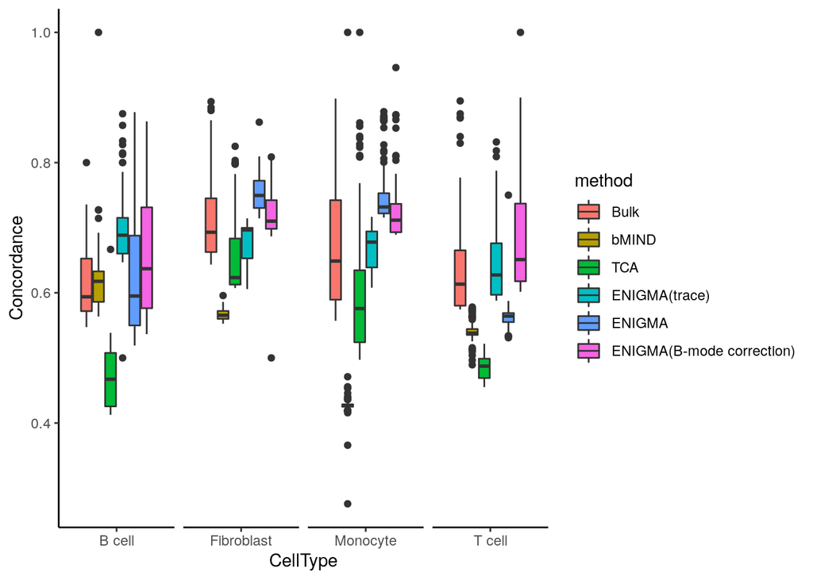

```r
B <- cbind(exprs(OA)[,OA$type == "B cell"],exprs(RA)[,RA$type == "B cell"])
label_sc <- c(rep("OA",sum(OA$type == "B cell")),rep("RA",sum(RA$type == "B cell")))
label <- as.character(pheno)
genes <- intersect(rownames(B),rownames(ref_ra))

###FACS reference
bulk_B <- evaluate_concordance(genes,B,label_sc,log2(exprs(bulk_ra_vs_oa)[rownames(res_alg_all_ra_l2_norm$X_k),]+1),label)
ENIGMA_B <- evaluate_concordance(genes,B,label_sc,res_alg_all_ra_l2_norm_sort_2$X_k_norm[,,1],label)
ENIGMA_B2 <- evaluate_concordance(genes,B,label_sc,res_alg_all_ra_l2_norm_sort$X_k_norm[,,1],label)
ENIGMA2_B <- evaluate_concordance(genes,B,label_sc,res_alg_all_ra_l2_norm_sort_trace$X_k_norm[,,1],label)
bMIND_B <- evaluate_concordance(genes,B,label_sc,deconv2$A[,1,],label)
TCA_B <- evaluate_concordance(genes,B,label_sc,Z_hat2[[1]],label)

fibro <- cbind(exprs(OA)[,OA$type == "Fibroblast"],exprs(RA)[,RA$type == "Fibroblast"])
label_sc <- c(rep("OA",sum(OA$type == "Fibroblast")),rep("RA",sum(RA$type == "Fibroblast")))
label <- as.character(pheno)
genes <- intersect(rownames(fibro),rownames(ref_ra))

bulk_fibro <- evaluate_concordance(genes,fibro,label_sc,log2(exprs(bulk_ra_vs_oa)[rownames(res_alg_all_ra_l2_norm$X_k),]+1),label)
ENIGMA_fibro <- evaluate_concordance(genes,fibro,label_sc,res_alg_all_ra_l2_norm_sort_2$X_k_norm[,,2],label)
ENIGMA_fibro2 <- evaluate_concordance(genes,fibro,label_sc,res_alg_all_ra_l2_norm_sort$X_k_norm[,,2],label)
ENIGMA2_fibro <- evaluate_concordance(genes,fibro,label_sc,res_alg_all_ra_l2_norm_sort_trace$X_k_norm[,,2],label)
bMIND_fibro <- evaluate_concordance(genes,fibro,label_sc,deconv2$A[,2,],label)
TCA_fibro <- evaluate_concordance(genes,fibro,label_sc,Z_hat2[[2]],label)

mono <- cbind(exprs(OA)[,OA$type == "Monocyte"],exprs(RA)[,RA$type == "Monocyte"])
label_sc <- c(rep("OA",sum(OA$type == "Monocyte")),rep("RA",sum(RA$type == "Monocyte")))
label <- as.character(pheno)
genes <- intersect(rownames(mono),rownames(ref_ra))

bulk_mono <- evaluate_concordance(genes,mono,label_sc,log2(exprs(bulk_ra_vs_oa)[rownames(res_alg_all_ra_l2_norm$X_k),]+1),label)
ENIGMA_mono <- evaluate_concordance(genes,mono,label_sc,res_alg_all_ra_l2_norm_sort_2$X_k_norm[,,3],label)
ENIGMA_mono2 <- evaluate_concordance(genes,mono,label_sc,res_alg_all_ra_l2_norm_sort$X_k_norm[,,3],label)
ENIGMA2_mono <- evaluate_concordance(genes,mono,label_sc,res_alg_all_ra_l2_norm_sort_trace$X_k_norm[,,3],label)
bMIND_mono <- evaluate_concordance(genes,mono,label_sc,deconv2$A[,3,],label)
TCA_mono <- evaluate_concordance(genes,mono,label_sc,Z_hat2[[3]],label)


T <- cbind(exprs(OA)[,OA$type == "T cell"],exprs(RA)[,RA$type == "T cell"])
label_sc <- c(rep("OA",sum(OA$type == "T cell")),rep("RA",sum(RA$type == "T cell")))
label <- as.character(pheno)
genes <- intersect(rownames(T),rownames(ref_ra))


bulk_T <- evaluate_concordance(genes,T,label_sc,log2(exprs(bulk_ra_vs_oa)[rownames(res_alg_all_ra_l2_norm$X_k),]+1),label)
ENIGMA_T <- evaluate_concordance(genes,T,label_sc,res_alg_all_ra_l2_norm_sort_2$X_k_norm[,,4],label)
ENIGMA_T2 <- evaluate_concordance(genes,T,label_sc,res_alg_all_ra_l2_norm_sort$X_k_norm[,,4],label)
ENIGMA2_T <- evaluate_concordance(genes,T,label_sc,res_alg_all_ra_l2_norm_sort_trace$X_k_norm[,,4],label)
bMIND_T <- evaluate_concordance(genes,T,label_sc,deconv2$A[,4,],label)
TCA_T <- evaluate_concordance(genes,T,label_sc,Z_hat2[[4]],label)


##################
##ENIGMA perform better than TCA and bMIND regardless if perform frac-based normalization
boxDat <- data.frame(method=c(rep("Bulk",400),rep("TCA",400),rep("bMIND",400),rep("ENIGMA(trace)",400),rep("ENIGMA",400),rep("ENIGMA(B-mode correction)",400)),
                     Concordance=c(c(bulk_B,bulk_fibro,bulk_mono,bulk_T),
                                      c(TCA_B,TCA_fibro,TCA_mono,TCA_T),
                                      c(bMIND_B,bMIND_fibro,bMIND_mono,bMIND_T),
                                      c(ENIGMA2_B,ENIGMA2_fibro,ENIGMA2_mono,ENIGMA2_T),
                                      c(ENIGMA_B2,ENIGMA_fibro2,ENIGMA_mono2,ENIGMA_T2),
                                      c(ENIGMA_B,ENIGMA_fibro,ENIGMA_mono,ENIGMA_T))
                     ,
                     CellType = rep(c(rep("B cell",100),rep("Fibroblast",100),rep("Monocyte",100),rep("T cell",100)),6))

boxDat$method <- as.factor(boxDat$method)
boxDat$method <- factor(boxDat$method,levels = c("Bulk","bMIND","TCA","ENIGMA(trace)","ENIGMA","ENIGMA(B-mode correction)"))
boxDat <- boxDat[is.nan(boxDat$Concordance)==FALSE,]
p1 <- ggplot(boxDat, aes(x=CellType, y=Concordance,fill = method)) +
  geom_boxplot()+labs(y="Concordance")+
  theme_classic() +
  facet_grid(~CellType, scales = "free_x",as.table = FALSE) +
  theme(strip.background = element_blank(),strip.text.x = element_blank())
p1
```

Compare the concordance of different methods with single cell RNA-seq based reference profile matrix.

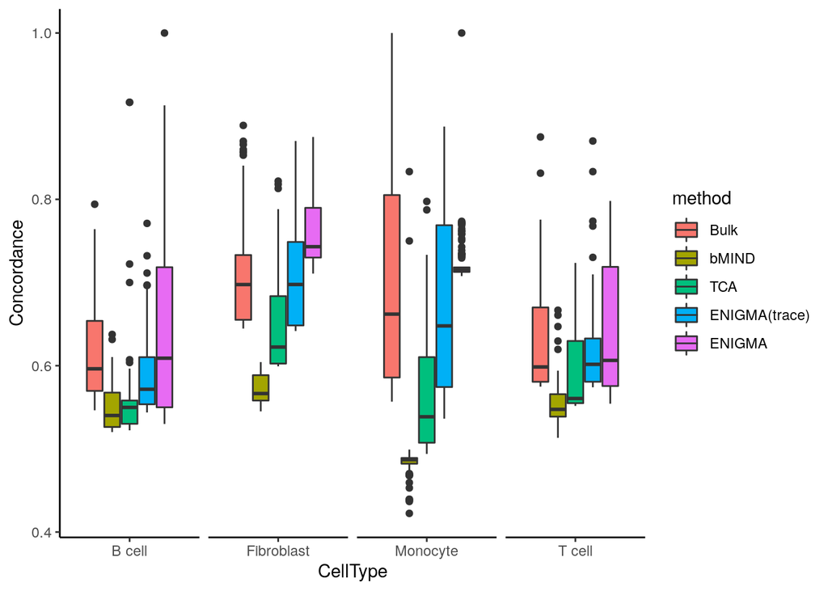

```r
B <- cbind(exprs(OA)[,OA$type == "B cell"],exprs(RA)[,RA$type == "B cell"])
label_sc <- c(rep("OA",sum(OA$type == "B cell")),rep("RA",sum(RA$type == "B cell")))
label <- as.character(pheno)
genes <- intersect(rownames(B),rownames(tmp_ra$type))

###FACS reference
bulk_B <- evaluate_concordance(genes,B,label_sc,log2(exprs(bulk_ra_vs_oa)[rownames(res_alg_all_ra_l2_norm$X_k),]+1),label)
ENIGMA_B <- evaluate_concordance(genes,B,label_sc,res_alg_all_ra_l2_norm$X_k[,,1],label)
ENIGMA2_B <- evaluate_concordance(genes,B,label_sc,res_alg_all_ra_l2_norm_trace$X_k[,,1],label)
bMIND_B <- evaluate_concordance(genes,B,label_sc,deconv$A[,1,],label)
TCA_B <- evaluate_concordance(genes,B,label_sc,Z_hat[[1]],label)

fibro <- cbind(exprs(OA)[,OA$type == "Fibroblast"],exprs(RA)[,RA$type == "Fibroblast"])
label_sc <- c(rep("OA",sum(OA$type == "Fibroblast")),rep("RA",sum(RA$type == "Fibroblast")))
label <- as.character(pheno)
genes <- intersect(rownames(fibro),rownames(tmp_ra$type))

bulk_fibro <- evaluate_concordance(genes,fibro,label_sc,log2(exprs(bulk_ra_vs_oa)[rownames(res_alg_all_ra_l2_norm$X_k),]+1),label)
ENIGMA_fibro <- evaluate_concordance(genes,fibro,label_sc,res_alg_all_ra_l2_norm$X_k[,,2],label)
ENIGMA2_fibro <- evaluate_concordance(genes,fibro,label_sc,res_alg_all_ra_l2_norm_trace$X_k[,,2],label)
bMIND_fibro <- evaluate_concordance(genes,fibro,label_sc,deconv$A[,2,],label)
TCA_fibro <- evaluate_concordance(genes,fibro,label_sc,Z_hat[[2]],label)

mono <- cbind(exprs(OA)[,OA$type == "Monocyte"],exprs(RA)[,RA$type == "Monocyte"])
label_sc <- c(rep("OA",sum(OA$type == "Monocyte")),rep("RA",sum(RA$type == "Monocyte")))
label <- as.character(pheno)
genes <- intersect(rownames(mono),rownames(tmp_ra$type))

bulk_mono <- evaluate_concordance(genes,mono,label_sc,log2(exprs(bulk_ra_vs_oa)[rownames(res_alg_all_ra_l2_norm$X_k),]+1),label)
ENIGMA_mono <- evaluate_concordance(genes,mono,label_sc,res_alg_all_ra_l2_norm$X_k[,,3],label)
ENIGMA2_mono <- evaluate_concordance(genes,mono,label_sc,res_alg_all_ra_l2_norm_trace$X_k[,,3],label)
bMIND_mono <- evaluate_concordance(genes,mono,label_sc,deconv$A[,3,],label)
TCA_mono <- evaluate_concordance(genes,mono,label_sc,Z_hat[[3]],label)


T <- cbind(exprs(OA)[,OA$type == "T cell"],exprs(RA)[,RA$type == "T cell"])
label_sc <- c(rep("OA",sum(OA$type == "T cell")),rep("RA",sum(RA$type == "T cell")))
label <- as.character(pheno)
genes <- intersect(rownames(T),rownames(tmp_ra$type))


bulk_T <- evaluate_concordance(genes,T,label_sc,log2(exprs(bulk_ra_vs_oa)[rownames(res_alg_all_ra_l2_norm$X_k),]+1),label)
ENIGMA_T <- evaluate_concordance(genes,T,label_sc,res_alg_all_ra_l2_norm$X_k[,,4],label)
ENIGMA2_T <- evaluate_concordance(genes,T,label_sc,res_alg_all_ra_l2_norm_trace$X_k[,,4],label)
bMIND_T <- evaluate_concordance(genes,T,label_sc,deconv$A[,4,],label)
TCA_T <- evaluate_concordance(genes,T,label_sc,Z_hat[[4]],label)


##################
##ENIGMA perform better than TCA and bMIND regardless if perform frac-based normalization
boxDat2 <- data.frame(method=c(rep("Bulk",400),rep("TCA",400),rep("bMIND",400),rep("ENIGMA(trace)",400),rep("ENIGMA",400)),
                     Concordance=c(c(bulk_B,bulk_fibro,bulk_mono,bulk_T),
                                      c(TCA_B,TCA_fibro,TCA_mono,TCA_T),
                                      c(bMIND_B,bMIND_fibro,bMIND_mono,bMIND_T),
                                      c(ENIGMA2_B,ENIGMA2_fibro,ENIGMA2_mono,ENIGMA2_T),
                                      c(ENIGMA_B,ENIGMA_fibro,ENIGMA_mono,ENIGMA_T))
                     ,
                     CellType = rep(c(rep("B cell",100),rep("Fibroblast",100),rep("Monocyte",100),rep("T cell",100)),5))

boxDat2$method <- as.factor(boxDat2$method)
boxDat2$method <- factor(boxDat2$method,levels = c("Bulk","bMIND","TCA","ENIGMA(trace)","ENIGMA","ENIGMA(B-mode correction)"))
boxDat2 <- boxDat2[is.nan(boxDat2$Concordance)==FALSE,]
p1 <- ggplot(boxDat2, aes(x=CellType, y=Concordance,fill = method)) +
  geom_boxplot()+labs(y="Concordance")+
  theme_classic() +
  facet_grid(~CellType, scales = "free_x",as.table = FALSE) +
  theme(strip.background = element_blank(),strip.text.x = element_blank())
p1
```

## Analysis monocyte trajectory

We first merely used RA generated fraction informs to perform deconvolution. We noted that when we need to reveal the latent state of a specific cell type, we used sqrt transformation.

```r
res_alg_all_ra2 <- cell_deconvolve(X=as.matrix(sqrt(exprs(bulk_ra_vs_oa))),
                    theta=Fra_ra3$theta,
                    R=as.matrix(sqrt(ref_ra)),
                    epsilon = 0.001,
                    alpha=0.5,
                    beta=0.1,tao_k=0.01,max.iter=1000,verbose=TRUE,pre.process = "sqrt", Norm.method = "frac")
```

```
## Tue Jan 25 16:20:08 2022 Optimizing cell type specific expression profile...
##    Ratio ranges from: 593579916.617640 - 594066949.839709
##    Ratio ranges from: 211320908.380465 - 217468304.587011
##    Ratio ranges from: 84066891.416715 - 86659696.891686
##    Ratio ranges from: 33530126.171501 - 34641711.582154
##    Ratio ranges from: 13055790.814841 - 13564911.422127
##    Ratio ranges from: 4949975.284148 - 5167098.405756
##    Ratio ranges from: 1882631.777252 - 1954781.387164
##    Ratio ranges from: 725847.584257 - 749834.972725
##    Ratio ranges from: 282836.797817 - 290814.647869
##    Ratio ranges from: 111141.764749 - 113510.849806
##    Ratio ranges from: 44052.063138 - 44522.447932
##    Ratio ranges from: 17537.376172 - 17871.113110
##    Ratio ranges from: 6934.361054 - 7434.412018
##    Ratio ranges from: 2750.971795 - 3206.359903
##    Ratio ranges from: 1094.335411 - 1436.356860
##    Ratio ranges from: 436.260091 - 666.988745
##    Ratio ranges from: 174.199586 - 319.608277
##    Ratio ranges from: 69.642504 - 157.172822
##    Ratio ranges from: 27.866905 - 78.898551
##    Ratio ranges from: 11.158008 - 40.241005
##    Ratio ranges from: 4.469827 - 20.774719
##    Ratio ranges from: 1.791191 - 10.824105
##    Ratio ranges from: 0.717948 - 5.679012
##    Ratio ranges from: 0.287809 - 2.995406
##    Ratio ranges from: 0.115383 - 1.586375
##    Ratio ranges from: 0.046256 - 0.842805
##    Ratio ranges from: 0.018542 - 0.448876
##    Ratio ranges from: 0.007431 - 0.239544
##    Ratio ranges from: 0.002977 - 0.128038
##    Ratio ranges from: 0.001193 - 0.070876
##    Ratio ranges from: 0.000477 - 0.041156
##    Ratio ranges from: 0.000191 - 0.023968
##    Ratio ranges from: 0.000076 - 0.013993
##    Ratio ranges from: 0.000031 - 0.008187
##    Ratio ranges from: 0.000012 - 0.004799
##    Ratio ranges from: 0.000005 - 0.002817
##    Ratio ranges from: 0.000002 - 0.001657
##    Ratio ranges from: 0.000001 - 0.000976
## Optimizing cell type proportions...
## Total delta_loss: 2549260282.600133, Tue Jan 25 16:21:40 2022
## part1:3948551764.58077 part2:352269532.371212 part3:11465.0984747736
## Perform Normalization...Done!
## Converge in 38 steps
```

Using scater and seurat to perform dimensional reduction, clustering and UMAP visualization to the inferred monocyte expression profile

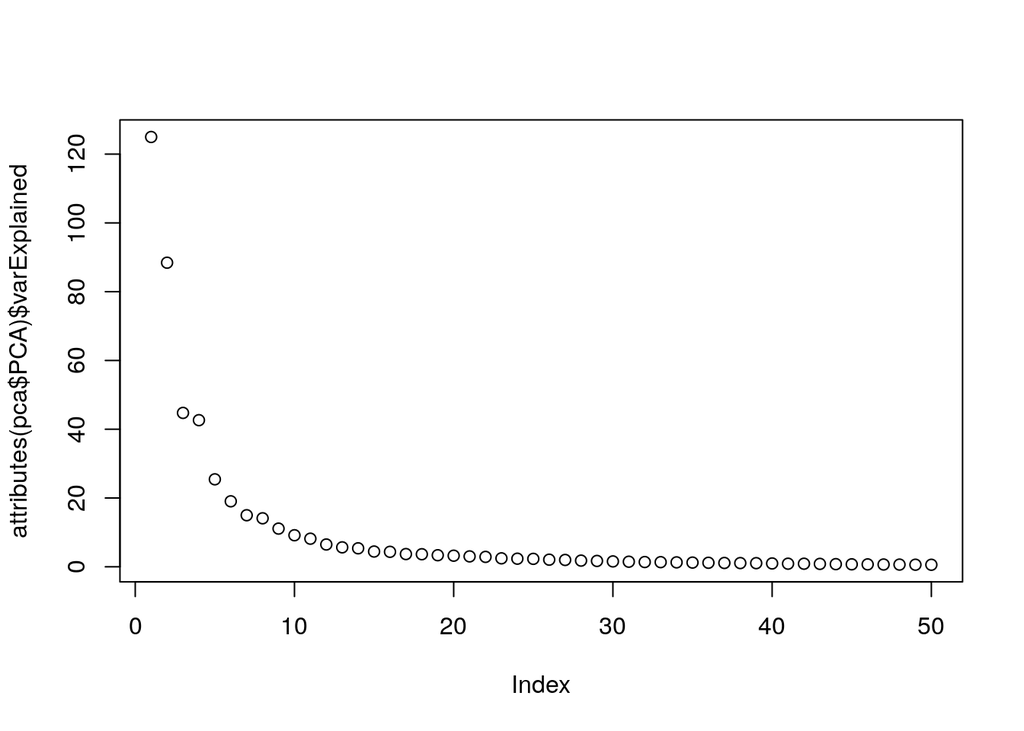

```r
sce_monocyte2 <- SingleCellExperiment(assays = list(logcounts = res_alg_all_ra2$X_k_norm[,,3]))
sce_monocyte2 <- runPCA(sce_monocyte2,scale=TRUE)
pca <- reducedDims(sce_monocyte2)
plot(attributes(pca$PCA)$varExplained)
```

```r
#####Running the Seurat to perform analysis

sce_monocyte2 = CreateSeuratObject(res_alg_all_ra2$X_k_norm[,,3])
sce_monocyte2[['pca']] = CreateDimReducObject(embeddings = pca$PCA,key="PC_")
sce_monocyte2 = RunUMAP(sce_monocyte2,dims=1:10)
```

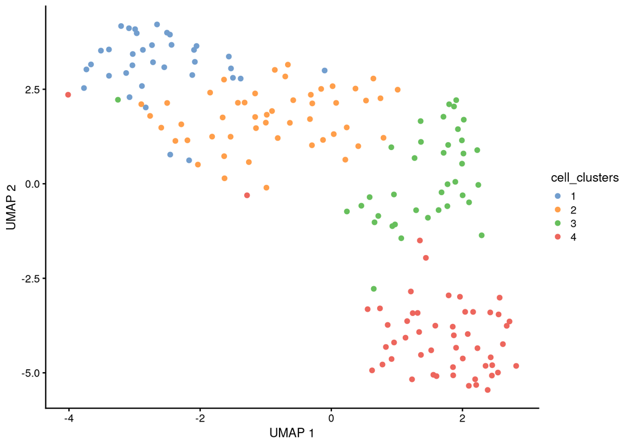

```r
###save the coordinate of UMAP
sce_monocyte2@reductions$umap@cell.embeddings -> umap
sce_monocyte2@reductions$pca@cell.embeddings -> pca

sce_monocyte2 <- SingleCellExperiment(assays = list(logcounts = res_alg_all_ra2$X_k_norm[,,3]))
reducedDim(sce_monocyte2, "PCA") <- pca
reducedDim(sce_monocyte2, "UMAP") <- umap
g <- buildSNNGraph(sce_monocyte2, k = 10, use.dimred = "PCA")
reducedDim(sce_monocyte2, "SNN") <- as_adjacency_matrix(g, attr = "weight")
sce_monocyte2$cell_clusters <- factor(cluster_louvain(g)$membership)

## plot the UMAP
plotReducedDim(sce_monocyte2, dimred = "UMAP", colour_by = "cell_clusters",point_alpha=1)
```

```r
assay <- normalize.quantiles(res_alg_all_ra2$X_k[,,3])
rownames(assay) <- rownames(res_alg_all_ra2$X_k[,,3])
colnames(assay) <- colnames(res_alg_all_ra2$X_k[,,3])
```

## Using the same pipeline to process the bulk

```r
sce_bulk2 <- SingleCellExperiment(assays = list(logcounts = log2(exprs(bulk_ra_vs_oa)+1)))
sce_bulk2$cell_type <- factor(cluster_louvain(g)$membership)
sce_bulk2 <- runPCA(sce_bulk2,scale=TRUE)
pca <- reducedDims(sce_bulk2)

sce_bulk2 = CreateSeuratObject(log2(exprs(bulk_ra_vs_oa)+1))
sce_bulk2[['pca']] = CreateDimReducObject(embeddings = pca$PCA,key="PC_")
sce_bulk2 = RunUMAP(sce_bulk2,dims=1:10)
```

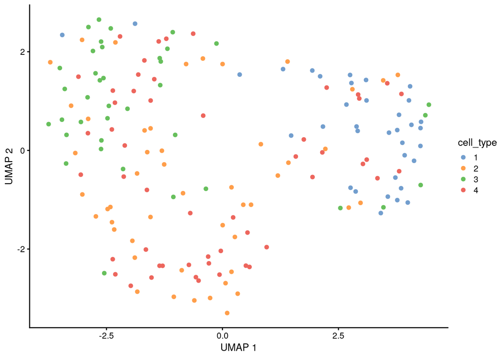

```r
###save the coordinate of UMAP
sce_bulk2@reductions$umap@cell.embeddings -> umap
sce_bulk2@reductions$pca@cell.embeddings -> pca

sce_bulk2 <- SingleCellExperiment(assays = list(logcounts = res_alg_all_ra2$X_k_norm[,,3]))
reducedDim(sce_bulk2, "PCA") <- pca
reducedDim(sce_bulk2, "UMAP") <- umap
g <- buildSNNGraph(sce_bulk2, k = 10, use.dimred = "PCA")
reducedDim(sce_bulk2, "SNN") <- as_adjacency_matrix(g, attr = "weight")
sce_bulk2$cell_clusters <- factor(cluster_louvain(g)$membership)
sce_bulk2$cell_type <- sce_monocyte2$cell_clusters
plotReducedDim(sce_bulk2, dimred = "UMAP", colour_by = "cell_type",point_alpha=1)
```

### Measure cell differentiation potency

We used SCENT and CytoTRACE to evaluate differentiation potency of each samples. The SCENT required PPI network, we used the PPI network downloaded from STRING database. the getPPI_String function could be downloaded from https://github.com/WWXkenmo/ICAnet/blob/master/getPPI_String.R

```r
ribosome <- readRDS("/mnt/data1/weixu/HiDe/revised/reproduce_monocyte/ribosome.rds")
PPI <- readRDS("/mnt/data1/weixu/HiDe/revised/reproduce_monocyte/PPI.rds")
score <- SCENT::CompCCAT(as.matrix(res_alg_all_ra2$X_k[,,3]),PPI[rownames(PPI)[rownames(PPI)%in%ribosome$V1 == FALSE],rownames(PPI)[rownames(PPI)%in%ribosome$V1 == FALSE]])
rs <- CytoTRACE::CytoTRACE(res_alg_all_ra2$X_k[rownames(res_alg_all_ra2$X_k[,,3])[rownames(res_alg_all_ra2$X_k[,,3])%in%ribosome$V1 == FALSE],,3])
```

```
## The number of cells in your dataset is less than 3,000. Fast mode has been disabled.
```

```
## CytoTRACE will be run on 1 sub-sample(s) of approximately 174 cells each using 1 / 1 core(s)
```

```
## Pre-processing data and generating similarity matrix...
```

```
## Smoothing values with NNLS regression and diffusion...
```

```
## Done
```

```r
ribosome_exp <- colMeans((res_alg_all_ra2$X_k_norm[intersect(ribosome$V1,rownames(res_alg_all_ra2$X_k_norm[,,3])),,3]))
sce_monocyte2$ribosome <- ribosome_exp
sce_monocyte2$cytotrace <- rs$CytoTRACE
sce_monocyte2$scent <- score
cor(sce_monocyte2$scent,sce_monocyte2$cytotrace)
```

```
## [1] 0.8998667
```

```r
score <- SCENT::CompCCAT(log2(exprs(bulk_ra_vs_oa)+1),PPI[rownames(PPI)[rownames(PPI)%in%ribosome$V1 == FALSE],rownames(PPI)[rownames(PPI)%in%ribosome$V1 == FALSE]])
rs <- CytoTRACE::CytoTRACE(log2(exprs(bulk_ra_vs_oa)+1)[rownames(exprs(bulk_ra_vs_oa))[rownames(res_alg_all_ra2$X_k[,,3])%in%ribosome$V1 == FALSE],])
```

```
## The number of cells in your dataset is less than 3,000. Fast mode has been disabled.
```

```
## CytoTRACE will be run on 1 sub-sample(s) of approximately 174 cells each using 1 / 1 core(s)
```

```
## Pre-processing data and generating similarity matrix...
```

```
## Smoothing values with NNLS regression and diffusion...
```

```
## Done
```

```r
ribosome_exp <- colMeans((log2(exprs(bulk_ra_vs_oa)+1)[intersect(ribosome$V1,rownames(res_alg_all_ra2$X_k_norm[,,3])),]))
sce_bulk2$ribosome <- ribosome_exp
sce_bulk2$cytotrace <- rs$CytoTRACE
sce_bulk2$scent <- score
cor(sce_bulk2$scent,sce_bulk2$cytotrace)
```

```
## [1] -0.02806822
```

Plot the average ribosome expression and differentiation potency of CytoTRACE and SCENT on UMAP.

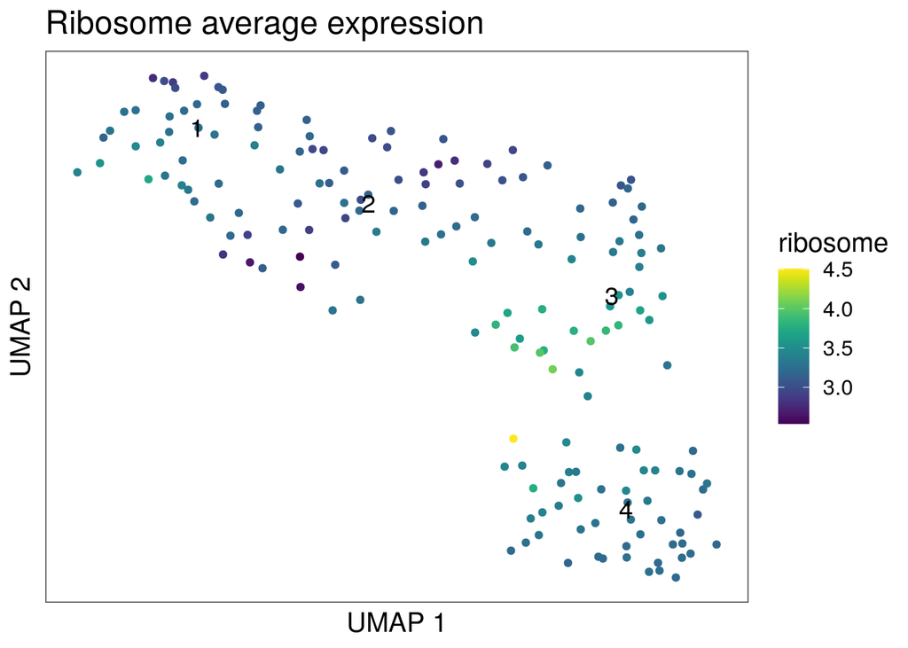

```r
plotReducedDim(sce_monocyte2, dimred = "UMAP", colour_by = "ribosome",point_alpha=1,text_by = "cell_clusters") + theme_bw()+theme(axis.text = element_blank(),axis.ticks = element_blank(),panel.grid = element_blank(),text = element_text(size=15))+ labs(title = "Ribosome average expression")
```

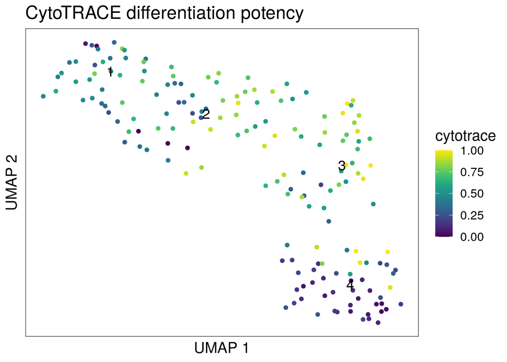

```r
plotReducedDim(sce_monocyte2, dimred = "UMAP", colour_by = "cytotrace",point_alpha=1,text_by = "cell_clusters") + theme_bw()+theme(axis.text = element_blank(),axis.ticks = element_blank(),panel.grid = element_blank(),text = element_text(size=15))+ labs(title = "CytoTRACE differentiation potency")
```

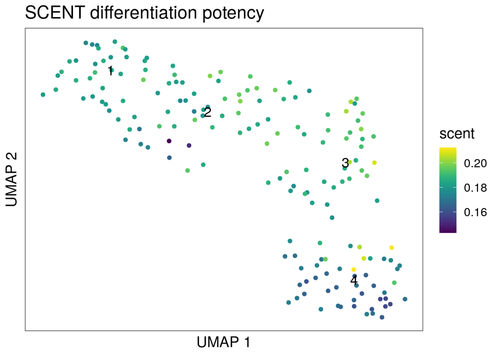

```r
plotReducedDim(sce_monocyte2, dimred = "UMAP", colour_by = "scent",point_alpha=1,text_by = "cell_clusters") + theme_bw()+theme(axis.text = element_blank(),axis.ticks = element_blank(),panel.grid = element_blank(),text = element_text(size=15)) + labs(title = "SCENT differentiation potency")
```

Plot the boxplots

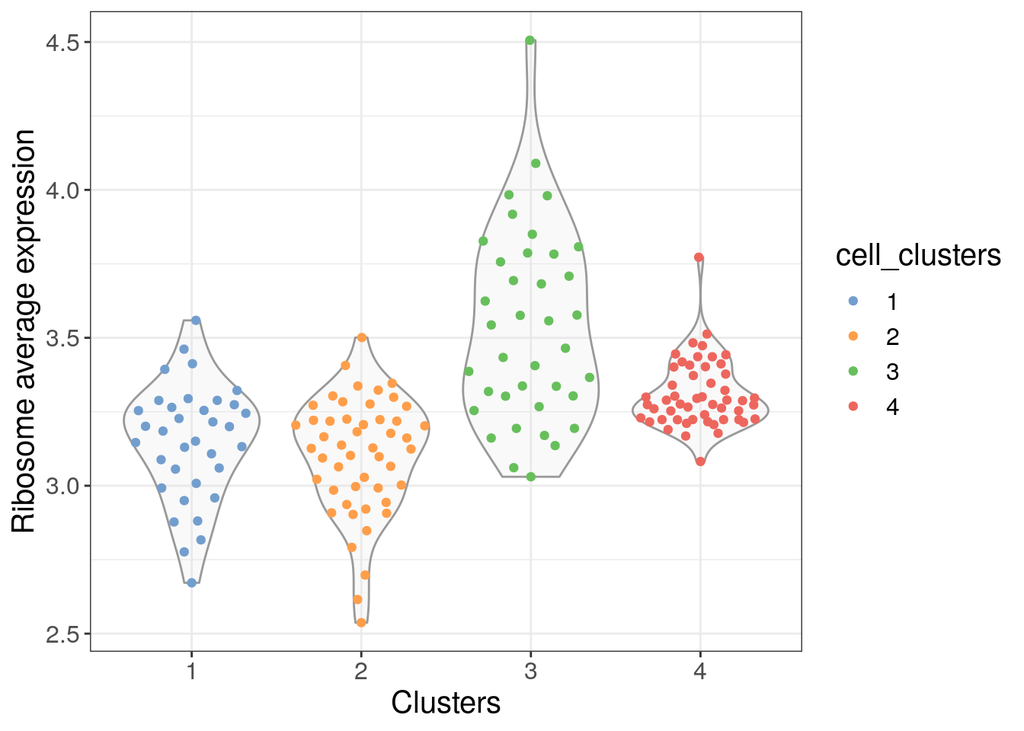

```r
plotColData(sce_monocyte2,colour_by = "cell_clusters",x = "cell_clusters", y = c("ribosome"),point_alpha=1)+theme_bw()+theme(text = element_text(size=15))+labs( y = "Ribosome average expression",x="Clusters")
```

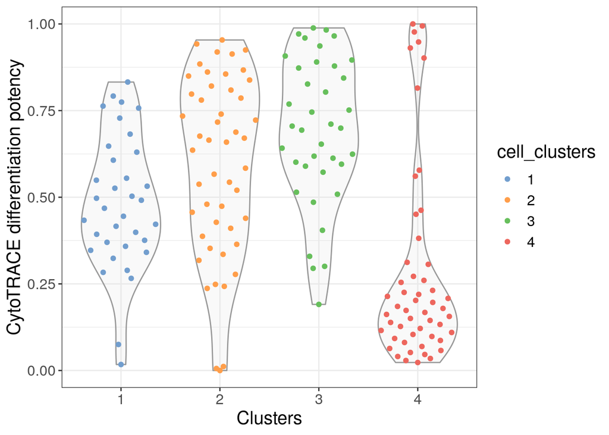

```r
plotColData(sce_monocyte2,colour_by = "cell_clusters",x = "cell_clusters", y = c("cytotrace"),point_alpha=1)+theme_bw()+theme(text = element_text(size=15))+labs( y = "CytoTRACE differentiation potency",x="Clusters")
```

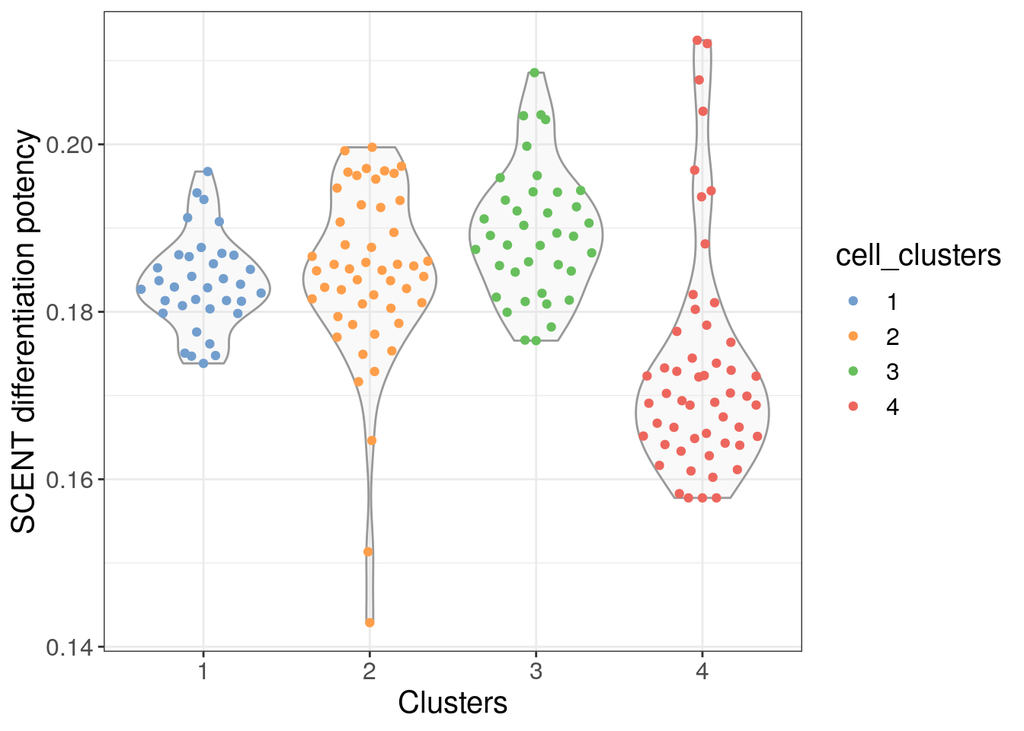

```r
plotColData(sce_monocyte2,colour_by = "cell_clusters",x = "cell_clusters", y = c("scent"),point_alpha=1)+theme_bw()+theme(text = element_text(size=15))+labs( y = "SCENT differentiation potency",x="Clusters")
```

## Trajectory analysis

fit slingshot to identify the lineage branches

```r
set.seed(1)
rootLabel <- as.character(as.matrix(sce_monocyte2$cell_clusters))
### 26th sample have the highest differentiation score in both SCENT prediction and CytoTRACE prediction
rootLabel[26] <- "root"
sce_monocyte2$rootLabel <- rootLabel
sce_pt <- slingshot(sce_monocyte2, clusterLabels = 'rootLabel', reducedDim = 'UMAP',start.clus = "root")
```

```
## Using diagonal covariance matrix
```

```r
lineages <- getLineages(reducedDims(sce_monocyte2)$UMAP, sce_monocyte2$rootLabel, start.clus = "root")
```

```
## Using diagonal covariance matrix
```

```r
curves <- getCurves(lineages)
```

plot the principal curve on UMAP

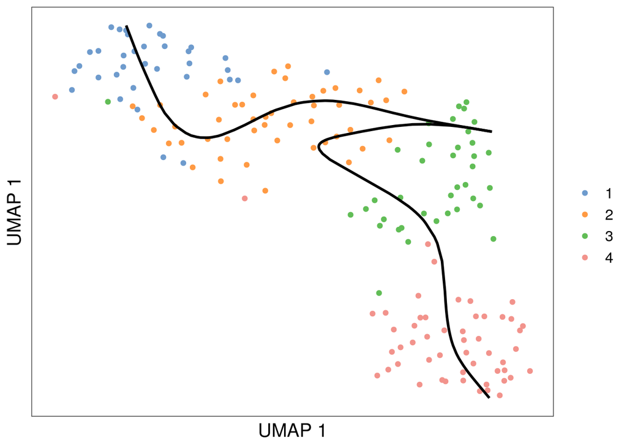

```r
gg_plot <- function(sds, col = NULL,colour=NULL, title = NULL, lineSize = 1, reduction = "UMAP"
                    , titleFsize = 20
                    , line.colors = gray.colors(n = length(sds@curves), start = 0, end = .6, alpha = 1 )
                    , ...) {
    rd <- reducedDim(sds)

    if (is.null(col)) {
        cl <- slingClusterLabels(sds)
        if ("matrix" %in% is(cl)) {
            cl <- apply(cl, 1, which.max)
            cl <- as.character(cl)
        }
    } else {
        cl <- col
    }

    # Getting the main plot
    df <- data.frame(dim1 = rd[, 1], dim2 = rd[, 2], col = cl)
    p <- ggplot(df, aes(x = dim1, y = dim2, col = col)) +
        geom_point(...) +
        theme_bw() + theme(axis.text = element_blank(),axis.ticks = element_blank(),panel.grid = element_blank(),text = element_text(size=15)) + scale_colour_manual(values = colour)+
        labs(title = title, col = "") +
        theme(plot.title = element_text(size = titleFsize)) # , face = "bold"
    # Adding the curves
    for (i in seq_along(slingCurves(sds))) {
        curve_i <- slingCurves(sds)[[i]]
        curve_i <- curve_i$s[curve_i$ord, ]
        colnames(curve_i) <- c("dim1", "dim2")
        p <- p + geom_path(data = as.data.frame(curve_i), col = line.colors[i], size = 1) +
            labs(x = paste(reduction, 1), y = paste(reduction, 1))

    }
    return(p)
}

col = c(rgb(110,155,205,max=255),rgb(255,154,67,max=255),rgb(97,189,86,max=255),rgb(242,147,140,max=255))
gg_plot(curves,col=sce_monocyte2$cell_clusters,colour=col,line.colors = rep("black","2"))
```

```r
library(tradeSeq)
exp <- exprs(sce_monocyte2)
exp[exp<0] <- 0
sce <- tradeSeq::fitGAM(
counts = as.matrix(exp),
sds = curves
)
### To reproduce our analysis, user could input our GAM fitting results
sce <- readRDS("/mnt/data1/weixu/HiDe/revised/reproduce_monocyte/sce.rds")
different_end_association <- tradeSeq::diffEndTest(sce)
```

Select the top gene to plot heatmaps

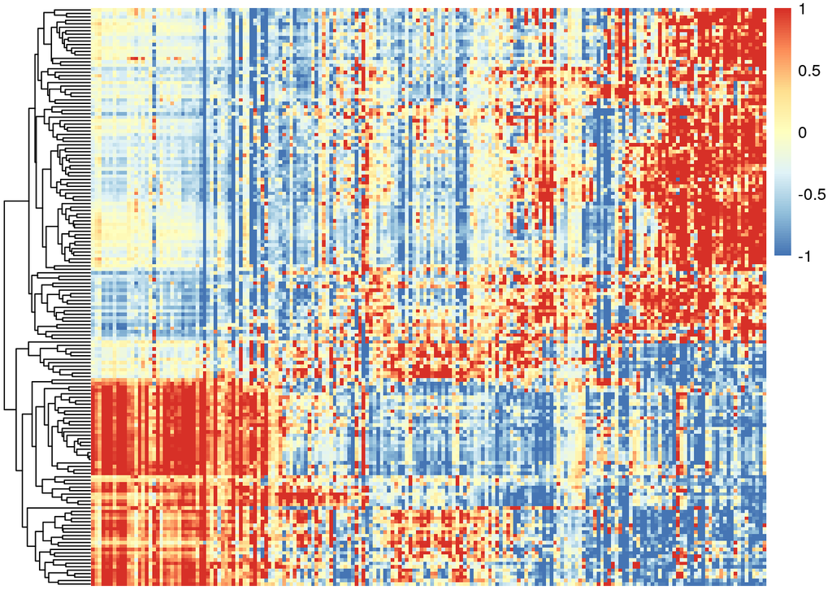

```r
topgenes <- rownames(different_end_association)[different_end_association$pvalue<0.1]
pst.ord <- order(sce_pt$slingPseudotime_1, na.last = NA)
##reverse the order
pst.ord <- rev(pst.ord)

heatdata <- assays(sce_pt)$logcounts[topgenes, pst.ord]
heatclus <- sce_pt$cell_clusters[pst.ord]
##reverse the order

pst.ord2 <- order(sce_pt$slingPseudotime_2, na.last = NA)
heatdata2 <- assays(sce_pt)$logcounts[topgenes, pst.ord2]
heatclus2 <- sce_pt$cell_clusters[pst.ord2]

##concatenate
heatdata <- cbind(heatdata,heatdata2)
heatclus <- c(heatclus,heatclus2)
pseudotime <- c(sce_pt$slingPseudotime_1[pst.ord],sce_pt$slingPseudotime_2[pst.ord2])

heatdata_scale <- t(apply(heatdata,1,scale))
rownames(heatdata_scale) <- rownames(heatdata)
colnames(heatdata_scale) <- colnames(heatdata)
heatdata_scale[heatdata_scale>1] <- 1
heatdata_scale[heatdata_scale< -1] <- -1
pheatmap::pheatmap(heatdata_scale, Colv = NA,
                             ColSideColors = RColorBrewer::brewer.pal(4,"Set1")[heatclus],cluster_cols = FALSE,show_rownames = FALSE,show_colnames = FALSE)
```

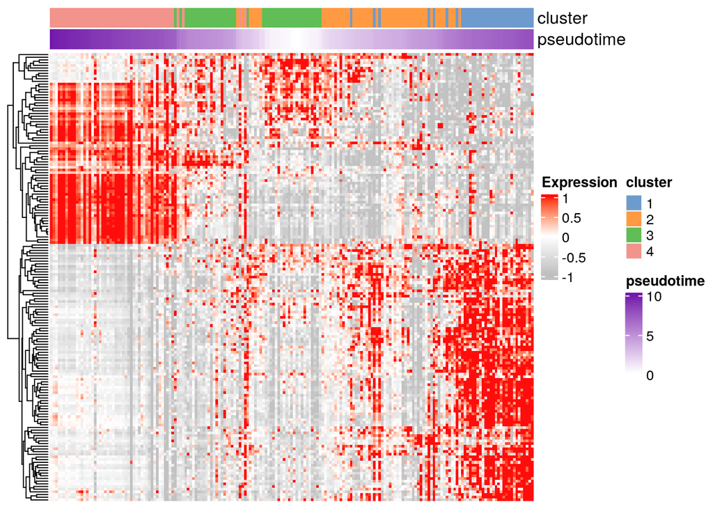

```r
bar <- col
names(bar) <-  names(table(heatclus))
color <- circlize::colorRamp2(c(-1,0,1), c("grey","white", "red"), transparency = 0.05, space = "LAB")
top_anno <- ComplexHeatmap::HeatmapAnnotation(cluster = heatclus,pseudotime = pseudotime, col = list(cluster = bar),show_legend = TRUE,show_annotation_name = TRUE)
p <- ComplexHeatmap::Heatmap(heatdata_scale,show_column_names = FALSE,show_row_names = FALSE,col=color,cluster_rows = TRUE,cluster_columns = FALSE,top_annotation = top_anno,heatmap_legend_param = list(title = "Expression"))
p <- draw(p)  #Show the heatmap
```

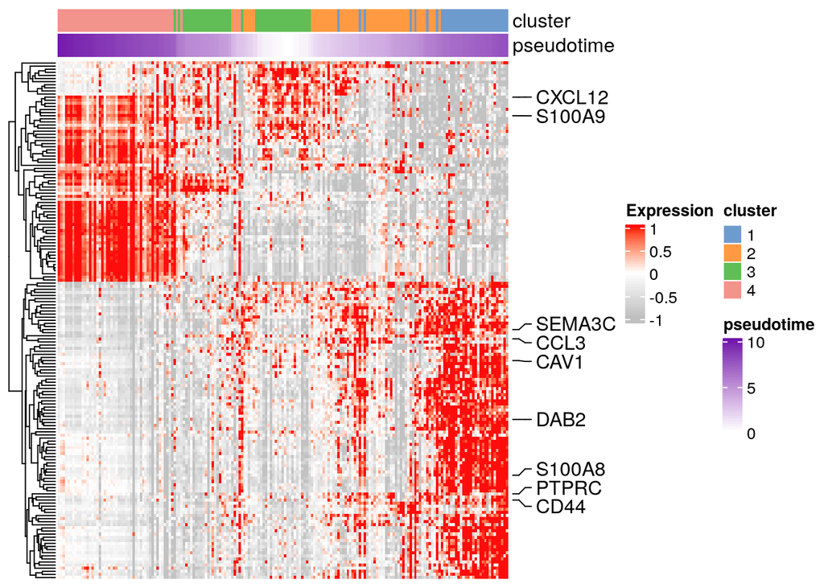

```r
rcl.list <- row_order(p)
rcl.list <- rownames(heatdata_scale)[rcl.list]
keyGene_pos <- which(rcl.list %in% c("CD44","PTPRC","S100A8","S100A9","CCL3","CXCL12","CAV1","SEMA3C","DAB2"))
keyGene <- rcl.list[keyGene_pos]
row_anno <- rowAnnotation(keypath = anno_mark(at = keyGene_pos,labels = keyGene))
p <- ComplexHeatmap::Heatmap(heatdata_scale,show_column_names = FALSE,show_row_names = FALSE,col=color,cluster_rows = TRUE,cluster_columns = FALSE,top_annotation = top_anno,right_annotation = row_anno, heatmap_legend_param = list(title = "Expression"))
p
```

## Go enrichment analysis

```r
bkgene <- rownames(sce_monocyte2)
bkgene <- bitr(bkgene,fromType="SYMBOL",toType="ENTREZID",org.Hs.eg.db)
upgene <- rownames(different_end_association)[different_end_association$pvalue<0.1 & different_end_association$logFC1_2>0]
upgene <- bitr(upgene,fromType="SYMBOL",toType="ENTREZID",org.Hs.eg.db)
upgene_go <- enrichGO(upgene[,2], ont="BP",pvalueCutoff = 0.01,qvalueCutoff = 0.05,OrgDb = org.Hs.eg.db,universe = bkgene$ENTREZID,readable=TRUE)


downgene <- rownames(different_end_association)[different_end_association$pvalue<0.1 & different_end_association$logFC1_2<0]
downgene <- bitr(downgene,fromType="SYMBOL",toType="ENTREZID",org.Hs.eg.db)
```

```
## wrong orderBy parameter; set to default `orderBy = "x"`
```

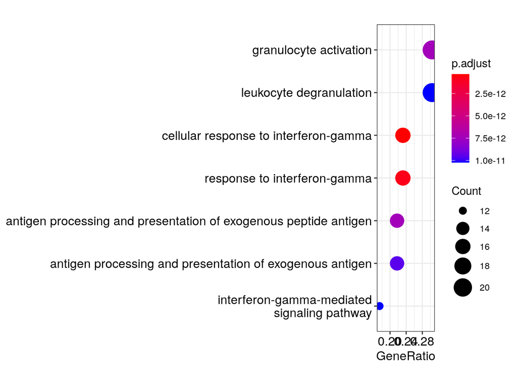

```r
downgene_go <- enrichGO(downgene[,2], ont="BP",pvalueCutoff = 0.01,qvalueCutoff = 0.05,OrgDb = org.Hs.eg.db,universe = bkgene$ENTREZID,readable=TRUE)

# The go terms of up-regulated genes
dotplot(upgene_go,showCategory = 7)
```

```
## wrong orderBy parameter; set to default `orderBy = "x"`
```

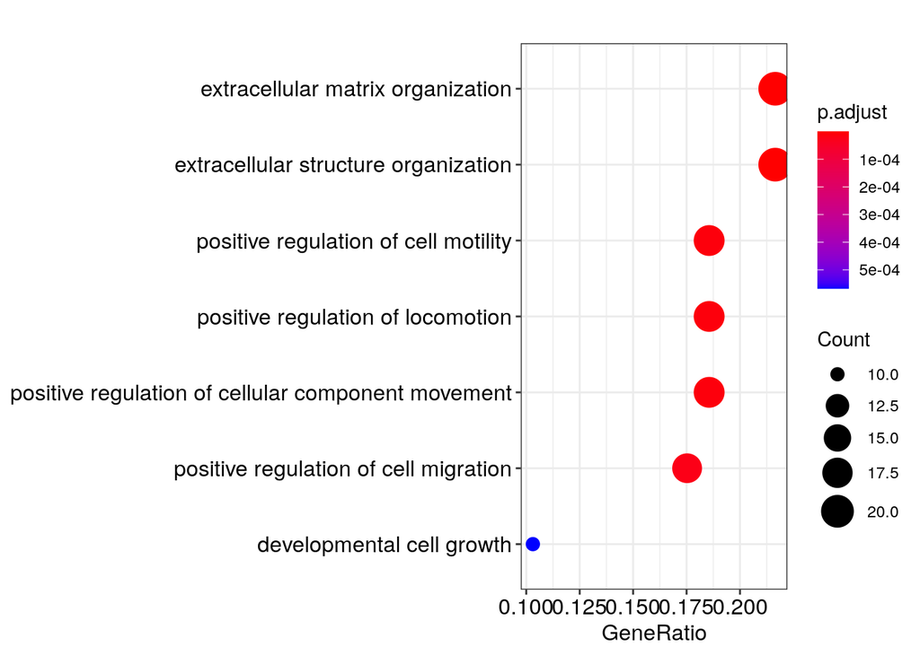

```r
# The go terms of down-regulated genes
dotplot(downgene_go,showCategory = 7)
```